# Data objects

## Topics

1. R data objects
   - vectors
   - matrices
   - data frames
   - lists
   - factors
   - model formula
2. Naming conventions, style guide

## R data objects

## Using R as a calculator

The simplest thing you could do with R is do arithmetic:

```r
100 + 10
[1] 110
```

```r
9 / 3
[1] 3
```

## Using R as a calculator

Here are the common signs to use in arithmetic:

| arithmetic | sign |
| --- | --- |
| Addition | `+` |
| Subtraction | `-` |
| Multiplication | * |
| Division | `/` |
| Exponents. | `^` or ** |

## Assignment operator

In the lab you have learned about the `<-` **assignment operator**.

Here `x` is assigned the value `8`

```r
x <- 8
```

If you run this code:

- a new value will be saved in your work space (piece of memory)
- In the environment pane, the tab “Environment”, you will see `x` under “Values” followed by 8

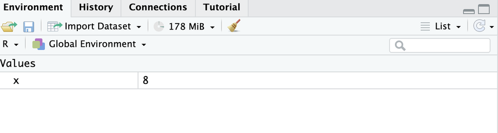

## Printing values

```r
x <- 8
```

Assigning does not print the value 8.

If you want to print to value 8 you can do:

```r
x

# or:

print(x)
```

## R is an object-oriented programming language

When you assign values with the assignment operator `<-` you create an R **object**.

Objects can contain data, functions or even other objects.

The most commonly used objects are:

- vector
- matrix
- data frame
- list
- formulas and models

## Vectors

## Vector

A vector is a list of values (data). The simplest object in R is a vector with one element:

```r
x <- 8
```

## Vector generating functions

The function `c(...)` collects elements in a vector

```r
v <- c(1, 2, 3, 4, 5)
```

- `seq(from, to)` or `:` generate a sequence of integers

```r
seq(from = 1, to = 5)
```

```
[1] 1 2 3 4 5
```

```r
1:5
```

```
[1] 1 2 3 4 5
```

- `rep(..., times)` repeats `...` a number of `times`

```r
rep(1:5, times = 2)
 [1] 1 2 3 4 5 1 2 3 4 5
```

## Classes

Vectors (and other R objects) can contain different data types (classes)

**Numeric**

```r
(v <- c(1, 2, 3, 4, 5))
[1] 1 2 3 4 5
class(v)
[1] "numeric"
```

## Classes

**Character**

```r
(char <- c("cat", "dog"))
[1] "cat" "dog"
typeof(char)
[1] "character"
```

## Classes

**Logical** data can take only one of two values: `TRUE` or `FALSE`.

```r
(v <- c(1,2,3,4,5))
[1] 1 2 3 4 5

# Identify elements > 3 in numeric vector v:
logical <- v > 3

print(logical)
[1] FALSE FALSE FALSE  TRUE  TRUE
```

## Vector classes

- all elements of a vector (are forced to) have the same class

```r
class(num <- c(1, 2))
[1] "numeric"

class(char <- c("cat", "dog"))
[1] "character"

c(num, char)
[1] "1"   "2"   "cat" "dog"

class(c(num, char))
[1] "character"
```

## Matrices

## Matrix generating functions

- `matrix(data, nrow, ncol)` generates a matrix
  - all elements (are forced to) have the same class

```r
M <- matrix(data = 1:6, nrow = 2, ncol = 3)
M
     [,1] [,2] [,3]
[1,]    1    3    5
[2,]    2    4    6
class(M)
[1] "matrix" "array"
```

`cbind(...)` collects vectors in a matrix as columns:

```r
cbind(a = 1:2, b = c("cat", "dog"))
     a   b
[1,] "1" "cat"
[2,] "2" "dog"
```

`rbind(...)` collects vectors as rows:

```r
rbind(a = 1:2, b = c("cat", "dog"))
  [,1]  [,2]
a "1"   "2"
b "cat" "dog"
```

## Data frames

## Data frame generating functions

- `data.frame(...)` collects vectors as variables in a data frame
  - variables can have different classes

```r
df <- data.frame(x = 1:2, y = c("cat", "dog"), z = c(T, F))
df
  x   y     z
1 1 cat  TRUE
2 2 dog FALSE
class(df)
[1] "data.frame"

sapply(df, class)
          x           y           z
  "integer" "character"   "logical"
```

## Lists

## List generating function

- `list(...)` creates a list
  - can contain objects of any dimension and class
  - used for collecting output from R function (e.g. linear regression)

```r
L <- list(v = c(1, 2), matrix = M, df = df, list(1:10))
class(L)
[1] "list"
sapply(L, class)
$v
[1] "numeric"

$matrix
[1] "matrix" "array"

$df
[1] "data.frame"

[[4]]
[1] "list"
```

## Factors

## Factors

- `factor(...)` makes / changes vector into factor
  - factors have levels
  - used for categorical variables in analyses (e.g. linear model)

```r
animals <- rep(c("cat", "dog"), 4)
summary(animals)
   Length     Class      Mode
        8 character character

factor(animals)
[1] cat dog cat dog cat dog cat dog
Levels: cat dog
summary(factor(animals))
cat dog
  4   4
```

## Assign names with `names()`

Use `names()` to assign names to elements in R objects.

For example to the elements of a list:

```r
names(L) <-c("Vector", "Matrix", "Dataframe", "List")
L
```

```
$Vector
[1] 1 2

$Matrix
     [,1] [,2] [,3]
[1,]    1    3    5
[2,]    2    4    6

$Dataframe
  x   y     z
1 1 cat  TRUE
2 2 dog FALSE

$List
$List[[1]]
 [1]  1  2  3  4  5  6  7  8  9 10
```

## Formulas and models

We use the `~` (tilde) operator to construct an **R model formula**, a type of **language object**.

Example: model body mass index (BMI) on weight with a linear regression model.

Use the model formula `bmi ~ wgt` with the linear model function `lm()`:

```r
require(mice)
lm(formula = bmi ~ wgt, data = boys)
```

```
Call:
lm(formula = bmi ~ wgt, data = boys)

Coefficients:
(Intercept)          wgt
    14.5401       0.0935
```

In this case, `bmi` ~ `wgt` means: “regress `bmi` on `weight`”.

## The model formula for plots

The model formula can also be used to create a scatter plot. Using the formula object `bmi ~ wgt`, leads automatically to the choice of scatter plot with `bmi` on the y-axis and `wgt` on the x-axis.

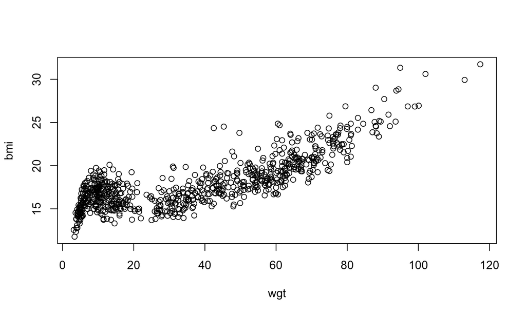

```r
plot(formula = bmi ~ wgt, data = boys)
```

## Use of data objects

When to use the R data objects?

| Object | Use | Why |
| --- | --- | --- |
| data frame | statistical analysis | can store variables of any class |
| model formula | statistical models, plots | concise and readable, flexible, consistent across functions, packages |
| lists | storage of output | can store any object of any class |
| vectors/matrices | programming | can do fast calculations |

## Naming conventions, style guide

## File and object naming

- File names should be **meaningful**.
- **Avoid spaces in file names** and use one of the **naming conventions**:
1. **snake_case**: words are separated by underscores (_), and all letters are typically in lowercase. Examples: data_analysis.RData, my_data.csv.
2. **camelCase:**: each word within a compound word is capitalized, except for the first word, and no spaces or underscores are used to separate the words. Examples: calculateMean, summaryStatistics.
3. **PascalCase**: the first letter of each word in a compound word is capitalized, and no spaces or underscores are used to separate the words. Examples: DataAnalysis, DescriptiveStatistics.

## Spacing and indentation

- When indenting your code, use 2 spaces. `RStudio` does this for you!
- Never use tabs or a mix of tabs and spaces.
- Place spaces around all operators (`=, +, -, <-`). Use `x <- 5` not `x<-5`

Exception: spaces around = are optional when passing parameters in a function call.

```r
lm(age ~ bmi, data=boys)
```

or

```r
lm(age ~ bmi, data = boys)
```

## Commas and punctuation

- Do not put spaces before commas, but always put a space after commas.
  - `c(1, 2, 3)`
- For function arguments, follow the same rule.
  - `sum(a = 1, b = 2)`

Bad examples:

```r
# No spaces around debug
if ( debug )

# Needs a space after the comma
x[1,]
```

## Comments

- Use # for single-line comments and place them above the code they reference.
- Keep comments concise and relevant.

```r
# Read the msleep.csv data and save the data as msleep
msleep <- readr::read_csv("msleep.csv")
```

## Lab

## Lab 1c

- Download the files of Lecture and Lab 1c.
- Save the files in your RSummer project folder and maintain a logical structure, for example like this:

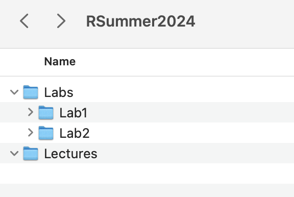